# Loan Data from Prosper

## Introduction

This dataset contains 113,937 loans records with 81 variables on each loan

## Preliminary Wrangling

```python
#Importing Libraries
import pandas as pd
import numpy as np
import seaborn as sns
from matplotlib import pyplot as plt
base_color = sns.color_palette()[0]

%matplotlib inline
```

```python
#Reading Data
prosperLoan = pd.read_csv('prosperLoanData.csv',parse_dates=['ClosedDate','ListingCreationDate','DateCreditPulled','LoanOriginationDate','FirstRecordedCreditLine'])
```

```python
prosperLoan.info()
```

```
<class 'pandas.core.frame.DataFrame'>
RangeIndex: 113937 entries, 0 to 113936
Data columns (total 81 columns):
 #   Column                               Non-Null Count   Dtype
---  ------                               --------------   -----
 0   ListingKey                           113937 non-null  object
 1   ListingNumber                        113937 non-null  int64
 2   ListingCreationDate                  113937 non-null  datetime64[ns]
 3   CreditGrade                          28953 non-null   object
 4   Term                                 113937 non-null  int64
 5   LoanStatus                           113937 non-null  object
 6   ClosedDate                           55089 non-null   datetime64[ns]
 7   BorrowerAPR                          113912 non-null  float64
 8   BorrowerRate                         113937 non-null  float64
 9   LenderYield                          113937 non-null  float64
```

[output cut: 73 more lines]

```python
#Checking data shape and composition
print(prosperLoan.shape)
print(prosperLoan.dtypes.value_counts())
prosperLoan.head(10)
```

```
(113937, 81)
float64           50
object            12
int64             11
datetime64[ns]     5
bool               3
dtype: int64
```

|  | ListingKey | ListingNumber | ListingCreationDate | CreditGrade | Term | LoanStatus | ClosedDate | BorrowerAPR | BorrowerRate | LenderYield | ... | LP_ServiceFees | LP_CollectionFees | LP_GrossPrincipalLoss | LP_NetPrincipalLoss | LP_NonPrincipalRecoverypayments | PercentFunded | Recommendations | InvestmentFromFriendsCount | InvestmentFromFriendsAmount | Investors |
| --- | --- | --- | --- | --- | --- | --- | --- | --- | --- | --- | --- | --- | --- | --- | --- | --- | --- | --- | --- | --- | --- |
| 0 | 1021339766868145413AB3B | 193129 | 2007-08-26 19:09:29.263 | C | 36 | Completed | 2009-08-14 | 0.16516 | 0.1580 | 0.1380 | ... | -133.18 | 0.0 | 0.0 | 0.0 | 0.0 | 1.0 | 0 | 0 | 0.0 | 258 |
| 1 | 10273602499503308B223C1 | 1209647 | 2014-02-27 08:28:07.900 | NaN | 36 | Current | NaT | 0.12016 | 0.0920 | 0.0820 | ... | 0.00 | 0.0 | 0.0 | 0.0 | 0.0 | 1.0 | 0 | 0 | 0.0 | 1 |
| 2 | 0EE9337825851032864889A | 81716 | 2007-01-05 15:00:47.090 | HR | 36 | Completed | 2009-12-17 | 0.28269 | 0.2750 | 0.2400 | ... | -24.20 | 0.0 | 0.0 | 0.0 | 0.0 | 1.0 | 0 | 0 | 0.0 | 41 |
| 3 | 0EF5356002482715299901A | 658116 | 2012-10-22 11:02:35.010 | NaN | 36 | Current | NaT | 0.12528 | 0.0974 | 0.0874 | ... | -108.01 | 0.0 | 0.0 | 0.0 | 0.0 | 1.0 | 0 | 0 | 0.0 | 158 |
| 4 | 0F023589499656230C5E3E2 | 909464 | 2013-09-14 18:38:39.097 | NaN | 36 | Current | NaT | 0.24614 | 0.2085 | 0.1985 | ... | -60.27 | 0.0 | 0.0 | 0.0 | 0.0 | 1.0 | 0 | 0 | 0.0 | 20 |
| 5 | 0F05359734824199381F61D | 1074836 | 2013-12-14 08:26:37.093 | NaN | 60 | Current | NaT | 0.15425 | 0.1314 | 0.1214 | ... | -25.33 | 0.0 | 0.0 | 0.0 | 0.0 | 1.0 | 0 | 0 | 0.0 | 1 |
| 6 | 0F0A3576754255009D63151 | 750899 | 2013-04-12 09:52:56.147 | NaN | 36 | Current | NaT | 0.31032 | 0.2712 | 0.2612 | ... | -22.95 | 0.0 | 0.0 | 0.0 | 0.0 | 1.0 | 0 | 0 | 0.0 | 1 |
| 7 | 0F1035772717087366F9EA7 | 768193 | 2013-05-05 06:49:27.493 | NaN | 36 | Current | NaT | 0.23939 | 0.2019 | 0.1919 | ... | -69.21 | 0.0 | 0.0 | 0.0 | 0.0 | 1.0 | 0 | 0 | 0.0 | 1 |
| 8 | 0F043596202561788EA13D5 | 1023355 | 2013-12-02 10:43:39.117 | NaN | 36 | Current | NaT | 0.07620 | 0.0629 | 0.0529 | ... | -16.77 | 0.0 | 0.0 | 0.0 | 0.0 | 1.0 | 0 | 0 | 0.0 | 1 |
| 9 | 0F043596202561788EA13D5 | 1023355 | 2013-12-02 10:43:39.117 | NaN | 36 | Current | NaT | 0.07620 | 0.0629 | 0.0529 | ... | -16.77 | 0.0 | 0.0 | 0.0 | 0.0 | 1.0 | 0 | 0 | 0.0 | 1 |

10 rows × 81 columns

```python
#check for missing data
feature_missingValue = {}
Feature_completeValue = {}
for item in prosperLoan.columns:
    if prosperLoan[item].isna().any():
        feature_missingValue[item] = f'{round(prosperLoan[item].isna().sum()/prosperLoan.shape[0] * 100, 2)}%'
    else:
        Feature_completeValue[item] = f'{round(prosperLoan[item].isna().sum()/prosperLoan.shape[0] * 100, 2)}%'

print(feature_missingValue,'\n')
print(f'Number of column with missing values is {len(feature_missingValue)}','\n')
print(Feature_completeValue,'\n')
print(f'Number of column without missing values is {len(Feature_completeValue)}','\n')
```

```
{'CreditGrade': '74.59%', 'ClosedDate': '51.65%', 'BorrowerAPR': '0.02%', 'EstimatedEffectiveYield': '25.53%', 'EstimatedLoss': '25.53%', 'EstimatedReturn': '25.53%', 'ProsperRating (numeric)': '25.53%', 'ProsperRating (Alpha)': '25.53%', 'ProsperScore': '25.53%', 'BorrowerState': '4.84%', 'Occupati…

Number of column with missing values is 43

{'ListingKey': '0.0%', 'ListingNumber': '0.0%', 'ListingCreationDate': '0.0%', 'Term': '0.0%', 'LoanStatus': '0.0%', 'BorrowerRate': '0.0%', 'LenderYield': '0.0%', 'ListingCategory (numeric)': '0.0%', 'IsBorrowerHomeowner': '0.0%', 'CurrentlyInGroup': '0.0%', 'DateCreditPulled': '0.0%', 'OpenRevolvi…

Number of column without missing values is 38
```

```python
# Drop column with missing values greater than 50%
for item in feature_missingValue:
    if prosperLoan[item].isna().sum()/prosperLoan.shape[0] * 100 >= 50:
        prosperLoan.drop(item,axis='columns',inplace = True)
```

```python
#Drop columns that signify keys
for item in prosperLoan.columns:
    if item[-3:] == 'Key':
        prosperLoan.drop(item,axis='columns',inplace = True)
```

```python
prosperLoan.isna().sum()
```

```
ListingNumber                   0
ListingCreationDate             0
Term                            0
LoanStatus                      0
BorrowerAPR                    25
                               ..
PercentFunded                   0
Recommendations                 0
InvestmentFromFriendsCount      0
InvestmentFromFriendsAmount     0
Investors                       0
Length: 66, dtype: int64
```

```python
prosperLoan.head()
```

|  | ListingNumber | ListingCreationDate | Term | LoanStatus | BorrowerAPR | BorrowerRate | LenderYield | EstimatedEffectiveYield | EstimatedLoss | EstimatedReturn | ... | LP_ServiceFees | LP_CollectionFees | LP_GrossPrincipalLoss | LP_NetPrincipalLoss | LP_NonPrincipalRecoverypayments | PercentFunded | Recommendations | InvestmentFromFriendsCount | InvestmentFromFriendsAmount | Investors |
| --- | --- | --- | --- | --- | --- | --- | --- | --- | --- | --- | --- | --- | --- | --- | --- | --- | --- | --- | --- | --- | --- |
| 0 | 193129 | 2007-08-26 19:09:29.263 | 36 | Completed | 0.16516 | 0.1580 | 0.1380 | NaN | NaN | NaN | ... | -133.18 | 0.0 | 0.0 | 0.0 | 0.0 | 1.0 | 0 | 0 | 0.0 | 258 |
| 1 | 1209647 | 2014-02-27 08:28:07.900 | 36 | Current | 0.12016 | 0.0920 | 0.0820 | 0.07960 | 0.0249 | 0.05470 | ... | 0.00 | 0.0 | 0.0 | 0.0 | 0.0 | 1.0 | 0 | 0 | 0.0 | 1 |
| 2 | 81716 | 2007-01-05 15:00:47.090 | 36 | Completed | 0.28269 | 0.2750 | 0.2400 | NaN | NaN | NaN | ... | -24.20 | 0.0 | 0.0 | 0.0 | 0.0 | 1.0 | 0 | 0 | 0.0 | 41 |
| 3 | 658116 | 2012-10-22 11:02:35.010 | 36 | Current | 0.12528 | 0.0974 | 0.0874 | 0.08490 | 0.0249 | 0.06000 | ... | -108.01 | 0.0 | 0.0 | 0.0 | 0.0 | 1.0 | 0 | 0 | 0.0 | 158 |
| 4 | 909464 | 2013-09-14 18:38:39.097 | 36 | Current | 0.24614 | 0.2085 | 0.1985 | 0.18316 | 0.0925 | 0.09066 | ... | -60.27 | 0.0 | 0.0 | 0.0 | 0.0 | 1.0 | 0 | 0 | 0.0 | 20 |

5 rows × 66 columns

```python
prosperLoan.columns
```

```
Index(['ListingNumber', 'ListingCreationDate', 'Term', 'LoanStatus',
       'BorrowerAPR', 'BorrowerRate', 'LenderYield', 'EstimatedEffectiveYield',
       'EstimatedLoss', 'EstimatedReturn', 'ProsperRating (numeric)',
       'ProsperRating (Alpha)', 'ProsperScore', 'ListingCategory (numeric)',
       'BorrowerState', 'Occupation', 'EmploymentStatus',
       'EmploymentStatusDuration', 'IsBorrowerHomeowner', 'CurrentlyInGroup',
       'DateCreditPulled', 'CreditScoreRangeLower', 'CreditScoreRangeUpper',
       'FirstRecordedCreditLine', 'CurrentCreditLines', 'OpenCreditLines',
       'TotalCreditLinespast7years', 'OpenRevolvingAccounts',
       'OpenRevolvingMonthlyPayment', 'InquiriesLast6Months', 'TotalInquiries',
       'CurrentDelinquencies', 'AmountDelinquent', 'DelinquenciesLast7Years',
       'PublicRecordsLast10Years', 'PublicRecordsLast12Months',
       'RevolvingCreditBalance', 'BankcardUtilization',
       'AvailableBankcardCredit', 'TotalTrades',
       'TradesNeverDelinquent (percentage)', 'TradesOpenedLast6Months',
       'DebtToIncomeRatio', 'IncomeRange', 'IncomeVerifiable',
       'StatedMonthlyIncome', 'LoanCurrentDaysDelinquent',
       'LoanMonthsSinceOrigination', 'LoanNumber', 'LoanOriginalAmount',
       'LoanOriginationDate', 'LoanOriginationQuarter', 'MonthlyLoanPayment',
       'LP_CustomerPayments', 'LP_CustomerPrincipalPayments',
       'LP_InterestandFees', 'LP_ServiceFees', 'LP_CollectionFees',
       'LP_GrossPrincipalLoss', 'LP_NetPrincipalLoss',
       'LP_NonPrincipalRecoverypayments', 'PercentFunded', 'Recommendations',
       'InvestmentFromFriendsCount', 'InvestmentFromFriendsAmount',
       'Investors'],
      dtype='object')
```

```python
#Picking out features needed for the analysis. Features picked must also have missing values less than 50 % i.e in prosperLoan.columns
sublist = [item for item in ['Term','LoanStatus','TotalProsperLoans','IncomeRange','ProsperPrincipalBorrowed','ProsperScore','CreditScoreRangeLower','CreditScoreRangeUpper'
                             'IncomeRange','ProsperRating (Alpha)','LenderYield','ListingCategory (numeric)', 'BorrowerState',
                             'Occupation', 'BorrowerAPR','CurrentDelinquencies','EmploymentStatus', 'EmploymentStatusDuration', 'DebtToIncomeRatio', 'IsBorrowerHomeowner',
                             'StatedMonthlyIncome', 'LoanOriginalAmount','AmountDelinquent','LoanOriginationDate', 'LoanOriginationQuarter', 'MonthlyLoanPayment',
                             'IncomeVerifiable','InvestmentFromFriendsAmount','RevolvingCreditBalance','TradesNeverDelinquent','TradesNeverDelinquent (percentage)','Investors'] if item in prosperLoan.columns
                             ]
prosperLoan_new = prosperLoan[sublist]
prosperLoan_new.head()
```

|  | Term | LoanStatus | IncomeRange | ProsperScore | CreditScoreRangeLower | ProsperRating (Alpha) | LenderYield | ListingCategory (numeric) | BorrowerState | Occupation | ... | LoanOriginalAmount | AmountDelinquent | LoanOriginationDate | LoanOriginationQuarter | MonthlyLoanPayment | IncomeVerifiable | InvestmentFromFriendsAmount | RevolvingCreditBalance | TradesNeverDelinquent (percentage) | Investors |
| --- | --- | --- | --- | --- | --- | --- | --- | --- | --- | --- | --- | --- | --- | --- | --- | --- | --- | --- | --- | --- | --- |
| 0 | 36 | Completed | $25,000-49,999 | NaN | 640.0 | NaN | 0.1380 | 0 | CO | Other | ... | 9425 | 472.0 | 2007-09-12 | Q3 2007 | 330.43 | True | 0.0 | 0.0 | 0.81 | 258 |
| 1 | 36 | Current | $50,000-74,999 | 7.0 | 680.0 | A | 0.0820 | 2 | CO | Professional | ... | 10000 | 0.0 | 2014-03-03 | Q1 2014 | 318.93 | True | 0.0 | 3989.0 | 1.00 | 1 |
| 2 | 36 | Completed | Not displayed | NaN | 480.0 | NaN | 0.2400 | 0 | GA | Other | ... | 3001 | NaN | 2007-01-17 | Q1 2007 | 123.32 | True | 0.0 | NaN | NaN | 41 |
| 3 | 36 | Current | $25,000-49,999 | 9.0 | 800.0 | A | 0.0874 | 16 | GA | Skilled Labor | ... | 10000 | 10056.0 | 2012-11-01 | Q4 2012 | 321.45 | True | 0.0 | 1444.0 | 0.76 | 158 |
| 4 | 36 | Current | $100,000+ | 4.0 | 680.0 | D | 0.1985 | 2 | MN | Executive | ... | 15000 | 0.0 | 2013-09-20 | Q3 2013 | 563.97 | True | 0.0 | 6193.0 | 0.95 | 20 |

5 rows × 27 columns

### Data Cleaning

```python
prosperLoan_new.isna().sum()
```

```
Term                                      0
LoanStatus                                0
IncomeRange                               0
ProsperScore                          29084
CreditScoreRangeLower                   591
ProsperRating (Alpha)                 29084
LenderYield                               0
ListingCategory (numeric)                 0
BorrowerState                          5515
Occupation                             3588
BorrowerAPR                              25
CurrentDelinquencies                    697
EmploymentStatus                       2255
EmploymentStatusDuration               7625
DebtToIncomeRatio                      8554
IsBorrowerHomeowner                       0
StatedMonthlyIncome                       0
LoanOriginalAmount                        0
AmountDelinquent                       7622
LoanOriginationDate                       0
LoanOriginationQuarter                    0
MonthlyLoanPayment                        0
IncomeVerifiable                          0
InvestmentFromFriendsAmount               0
RevolvingCreditBalance                 7604
TradesNeverDelinquent (percentage)     7544
Investors                                 0
dtype: int64
```

```python
prosperLoan_new.info()
```

```
<class 'pandas.core.frame.DataFrame'>
RangeIndex: 113937 entries, 0 to 113936
Data columns (total 27 columns):
 #   Column                              Non-Null Count   Dtype
---  ------                              --------------   -----
 0   Term                                113937 non-null  int64
 1   LoanStatus                          113937 non-null  object
 2   IncomeRange                         113937 non-null  object
 3   ProsperScore                        84853 non-null   float64
 4   CreditScoreRangeLower               113346 non-null  float64
 5   ProsperRating (Alpha)               84853 non-null   object
 6   LenderYield                         113937 non-null  float64
 7   ListingCategory (numeric)           113937 non-null  int64
 8   BorrowerState                       108422 non-null  object
 9   Occupation                          110349 non-null  object
```

[output cut: 19 more lines]

### Handling Missing data

```python
#check out missing values
missing_val = []
for item in prosperLoan_new.columns:
    if prosperLoan_new[item].isna().any():
        missing_val.append(item)
        print(item,'\n')
        print(f'{item}: {round(prosperLoan_new[item].isna().sum()/prosperLoan_new.shape[0] * 100, 2)}%','\n')
        print(prosperLoan_new[item].value_counts(),'\n')

print(missing_val)
```

```
ProsperScore

ProsperScore: 25.53%

4.0     12595
6.0     12278
8.0     12053
7.0     10597
5.0      9813
3.0      7642
9.0      6911
2.0      5766
10.0     4750
11.0     1456
1.0       992
Name: ProsperScore, dtype: int64

CreditScoreRangeLower

CreditScoreRangeLower: 0.52%

680.0    16492
660.0    16366
700.0    15471
720.0    12923
640.0    12199
740.0     9267
760.0     6606
780.0     4624
620.0     4172
600.0     3602
800.0     2644
520.0     1593
540.0     1474
820.0     1409
560.0     1357
580.0     1125
840.0      567
500.0      554
480.0      346
```

[output cut: 251 more lines]

```

1.00    41705
0.96     4245
0.95     3755
0.90     3171
0.94     3051
        ...
0.32        5
0.06        3
0.03        1
0.99        1
0.49        1
Name: TradesNeverDelinquent (percentage), Length: 98, dtype: int64

['ProsperScore', 'CreditScoreRangeLower', 'ProsperRating (Alpha)', 'BorrowerState', 'Occupation', 'BorrowerAPR', 'CurrentDelinquencies', 'EmploymentStatus', 'EmploymentStatusDuration', 'DebtToIncomeRatio', 'AmountDelinquent', 'RevolvingCreditBalance', 'TradesNeverDelinquent (percentage)']
```

```python
print(missing_val)
```

```
['ProsperScore', 'CreditScoreRangeLower', 'ProsperRating (Alpha)', 'BorrowerState', 'Occupation', 'BorrowerAPR', 'CurrentDelinquencies', 'EmploymentStatus', 'EmploymentStatusDuration', 'DebtToIncomeRatio', 'AmountDelinquent', 'RevolvingCreditBalance', 'TradesNeverDelinquent (percentage)']
```

```python
#Drop rows of missing value when column have a missing values less than 5%
for item in prosperLoan_new.columns:
    if prosperLoan_new[item].isna().any() and round(prosperLoan_new[item].isna().sum()/prosperLoan_new.shape[0] * 100, 2) <= 5 :
        print(f'Dropping rows from {item}')
        prosperLoan_new = prosperLoan_new.loc[prosperLoan_new[item].notnull()]
        print(prosperLoan_new[item].isna().any())
```

```
Dropping rows from CreditScoreRangeLower
False
Dropping rows from BorrowerState
False
Dropping rows from Occupation
False
Dropping rows from CurrentDelinquencies
False
Dropping rows from EmploymentStatusDuration
False
Dropping rows from RevolvingCreditBalance
False
```

```python
#set missing valuesin ProsperRating (Alpha) to NA not available
prosperLoan_new['ProsperRating (Alpha)'].fillna('Not available',inplace=True)
```

```python
#Testing
prosperLoan_new['ProsperRating (Alpha)'].isna().sum()
```

```
0
```

```python
#replace missing values occupation with Not available
prosperLoan_new['Occupation'] = prosperLoan_new['Occupation'].fillna('Not available')
# prosperLoan_new['Occupation'].replace([np.nan], 'Not available', inplace=True)
```

```python
#Testing
prosperLoan_new['Occupation'].isna().sum()
```

```
0
```

```python
prosperLoan_new['EmploymentStatus']
prosperLoan_new['EmploymentStatus'] = prosperLoan_new['EmploymentStatus'].fillna('Not available')
```

```python
prosperLoan_new.isna().any()
```

```
Term                                  False
LoanStatus                            False
IncomeRange                           False
ProsperScore                           True
CreditScoreRangeLower                 False
ProsperRating (Alpha)                 False
LenderYield                           False
ListingCategory (numeric)             False
BorrowerState                         False
Occupation                            False
BorrowerAPR                           False
CurrentDelinquencies                  False
EmploymentStatus                      False
EmploymentStatusDuration              False
DebtToIncomeRatio                      True
IsBorrowerHomeowner                   False
StatedMonthlyIncome                   False
LoanOriginalAmount                    False
AmountDelinquent                      False
LoanOriginationDate                   False
LoanOriginationQuarter                False
MonthlyLoanPayment                    False
IncomeVerifiable                      False
InvestmentFromFriendsAmount           False
RevolvingCreditBalance                False
TradesNeverDelinquent (percentage)    False
Investors                             False
dtype: bool
```

```python
#replace missing values in ProsperScore with median
prosperLoan_new['ProsperScore'].fillna(prosperLoan_new['ProsperScore'].median(), inplace = True)
prosperLoan_new['ProsperScore'].isna().sum()
```

```
0
```

```python
#replace missing values in DebtToIncomeRatio with median
prosperLoan_new['DebtToIncomeRatio'].fillna(prosperLoan_new['DebtToIncomeRatio'].median(), inplace = True)
prosperLoan_new['DebtToIncomeRatio'].isna().sum()
```

```
0
```

```python
prosperLoan_new.isna().sum()
```

```
Term                                  0
LoanStatus                            0
IncomeRange                           0
ProsperScore                          0
CreditScoreRangeLower                 0
ProsperRating (Alpha)                 0
LenderYield                           0
ListingCategory (numeric)             0
BorrowerState                         0
Occupation                            0
BorrowerAPR                           0
CurrentDelinquencies                  0
EmploymentStatus                      0
EmploymentStatusDuration              0
DebtToIncomeRatio                     0
IsBorrowerHomeowner                   0
StatedMonthlyIncome                   0
LoanOriginalAmount                    0
AmountDelinquent                      0
LoanOriginationDate                   0
LoanOriginationQuarter                0
MonthlyLoanPayment                    0
IncomeVerifiable                      0
InvestmentFromFriendsAmount           0
RevolvingCreditBalance                0
TradesNeverDelinquent (percentage)    0
Investors                             0
dtype: int64
```

### Handling data type and values

```python
# checking out type and the  values in each column
for item in prosperLoan_new.columns:
    print(item)
    print(" ")
    print(prosperLoan_new[item].value_counts())
    print(" ")
```

```
Term

36    77328
60    24285
12     1614
Name: Term, dtype: int64

LoanStatus

Current                   55268
Completed                 32374
Chargedoff                10225
Defaulted                  3103
Past Due (1-15 days)        798
Past Due (31-60 days)       358
Past Due (61-90 days)       313
Past Due (91-120 days)      304
Past Due (16-30 days)       264
FinalPaymentInProgress      203
Past Due (>120 days)         16
Cancelled                     1
Name: LoanStatus, dtype: int64

IncomeRange

$25,000-49,999    30909
$50,000-74,999    30297
$100,000+         17132
$75,000-99,999    16640
$1-24,999          6770
Not employed        778
$0                  600
Not displayed       101
Name: IncomeRange, dtype: int64

ProsperScore

6.0     31844
4.0     12256
8.0     11941
```

[output cut: 417 more lines]

```

Investors

1      26704
2       1273
3        913
4        749
5        681
       ...
782        1
666        1
620        1
888        1
754        1
Name: Investors, Length: 748, dtype: int64
```

```python
prosperLoan_new.info()
```

```
<class 'pandas.core.frame.DataFrame'>
Int64Index: 103227 entries, 0 to 113936
Data columns (total 27 columns):
 #   Column                              Non-Null Count   Dtype
---  ------                              --------------   -----
 0   Term                                103227 non-null  int64
 1   LoanStatus                          103227 non-null  object
 2   IncomeRange                         103227 non-null  object
 3   ProsperScore                        103227 non-null  float64
 4   CreditScoreRangeLower               103227 non-null  float64
 5   ProsperRating (Alpha)               103227 non-null  object
 6   LenderYield                         103227 non-null  float64
 7   ListingCategory (numeric)           103227 non-null  int64
 8   BorrowerState                       103227 non-null  object
 9   Occupation                          103227 non-null  object
```

[output cut: 19 more lines]

```python
prosperLoan_new['IncomeRange']
```

```
0         $25,000-49,999
1         $50,000-74,999
3         $25,000-49,999
4              $100,000+
5              $100,000+
               ...
113932    $50,000-74,999
113933    $75,000-99,999
113934    $25,000-49,999
113935    $25,000-49,999
113936    $50,000-74,999
Name: IncomeRange, Length: 103227, dtype: object
```

```python
# Replace True with Home Owner and False with Not Home Owner in IsBorrowerHomeowner
prosperLoan_new['IsBorrowerHomeowner'].replace([True,False], ['Home Owner','Not Home Owner'], inplace=True)


prosperLoan_new['IsBorrowerHomeowner'].value_counts()
```

```
Home Owner        53682
Not Home Owner    49545
Name: IsBorrowerHomeowner, dtype: int64
```

```python
# Replace ProsperRating (Alpha) values with corresponding risk level
ProsperRating_Alpha_rating = {'AA': "Lowest estimated loss rate", 'A': 'Very low estimated loss rate',
                              'B': 'Low estimated loss rate', 'C': 'Moderate estimated loss rate',
                              'D':'High estimated loss rate', 'E': 'Very high estimated loss rate',
                              'HR': 'Highest estimated loss rate'
                            }
prosperLoan_new['ProsperRating (Alpha)'] = prosperLoan_new['ProsperRating (Alpha)'].replace(ProsperRating_Alpha_rating)
prosperLoan_new['ProsperRating (Alpha)'].value_counts()
```

```
Not available                    19720
Moderate estimated loss rate     17951
Low estimated loss rate          15329
Very low estimated loss rate     14336
High estimated loss rate         14077
Very high estimated loss rate     9621
Highest estimated loss rate       6876
Lowest estimated loss rate        5317
Name: ProsperRating (Alpha), dtype: int64
```

```python
#Replacing BorrowerState with their full names
states = {'AL': 'Alabama','AK': 'Alaska','AZ': 'Arizona','AR': 'Arkansas','CA': 'California','CO': 'Colorado',
          'CT': 'Connecticut','DE': 'Delaware','FL': 'Florida','GA': 'Georgia','HI': 'Hawaii','ID': 'Idaho',
          'IL': 'Illinois','IN': 'Indiana','IA': 'Iowa','KS': 'Kansas','KY': 'Kentucky','LA': 'Louisiana',
          'ME': 'Maine','MD': 'Maryland','MA': 'Massachusetts','MI': 'Michigan','MN': 'Minnesota','MS': 'Mississippi',
          'MO': 'Missouri','MT': 'Montana','NE': 'Nebraska','NV': 'Nevada','NH': 'New Hampshire','NJ': 'New Jersey',
          'NM': 'New Mexico','NY': 'New York','NC': 'North Carolina','ND': 'North Dakota','OH': 'Ohio','OK': 'Oklahoma',
          'OR': 'Oregon','PA': 'Pennsylvania','RI': 'Rhode Island','SC': 'South Carolina','SD': 'South Dakota',
          'TN': 'Tennessee','TX': 'Texas','UT': 'Utah','VT': 'Vermont','VA': 'Virginia','WA': 'Washington',
          'WV': 'West Virginia','WI': 'Wisconsin','WY': 'Wyoming'
         }
prosperLoan_new['BorrowerState'] = prosperLoan_new['BorrowerState'].replace(states)
```

```python
#Replacing list_category_dict numeric values with exact string values that they represented
list_category_dict = {0:'Not available', 1 : 'Debt Consolidation', 2 : 'Home Improvement', 3 : 'Business', 4 : 'Personal Loan',
                 5 : 'Student Use', 6 : 'Auto', 7 :'Other', 8 : 'Baby&Adoption', 9 :'Boat', 10 : 'Cosmetic Procedure',
                 11 :'Engagement Ring', 12 : "Green Loans", 13 : 'Household Expenses', 14 : 'Large Purchases',
                 15 : 'Medical/Dental', 16 : 'Motorcycle', 17 : 'RV', 18 : 'Taxes', 19 : 'Vacation', 20 : 'Wedding Loans'}
prosperLoan_new['ListingCategory (numeric)'].replace(list_category_dict,inplace = True)
```

```python
#Rename list_category_dict numeric to ListingCategory
prosperLoan_new.rename(columns={'ListingCategory (numeric)': 'ListingCategory'}, inplace=True)
prosperLoan_new['ListingCategory']
```

```
0              Not available
1           Home Improvement
3                 Motorcycle
4           Home Improvement
5         Debt Consolidation
                 ...
113932    Debt Consolidation
113933                 Other
113934    Debt Consolidation
113935      Home Improvement
113936    Debt Consolidation
Name: ListingCategory, Length: 103227, dtype: object
```

```python
#engineering feature
prosperLoan_new['LoanOriginationYear'] = prosperLoan_new['LoanOriginationDate'].dt.strftime('%Y')
prosperLoan_new['LoanOriginationYear']
```

```
0         2007
1         2014
3         2012
4         2013
5         2013
          ...
113932    2013
113933    2011
113934    2013
113935    2011
113936    2014
Name: LoanOriginationYear, Length: 103227, dtype: object
```

```python
#Replace numeric term of loans with corresponding categorical values that they represented
Term = {12: 'Short Term',36:'Middle Term', 60:'Long Term'}
prosperLoan_new.Term.replace(Term,inplace = True)
prosperLoan_new.Term
```

```
0         Middle Term
1         Middle Term
3         Middle Term
4         Middle Term
5           Long Term
             ...
113932    Middle Term
113933    Middle Term
113934      Long Term
113935      Long Term
113936    Middle Term
Name: Term, Length: 103227, dtype: object
```

```python
#saving clean dataset
prosperLoan_new.to_csv('prosperLoan_new',index = False)
```

```python
prosperLoan_new.columns
```

```
Index(['Term', 'LoanStatus', 'IncomeRange', 'ProsperScore',
       'CreditScoreRangeLower', 'ProsperRating (Alpha)', 'LenderYield',
       'ListingCategory', 'BorrowerState', 'Occupation', 'BorrowerAPR',
       'CurrentDelinquencies', 'EmploymentStatus', 'EmploymentStatusDuration',
       'DebtToIncomeRatio', 'IsBorrowerHomeowner', 'StatedMonthlyIncome',
       'LoanOriginalAmount', 'AmountDelinquent', 'LoanOriginationDate',
       'LoanOriginationQuarter', 'MonthlyLoanPayment', 'IncomeVerifiable',
       'InvestmentFromFriendsAmount', 'RevolvingCreditBalance',
       'TradesNeverDelinquent (percentage)', 'Investors',
       'LoanOriginationYear'],
      dtype='object')
```

```python
#Seaparating features into categorical and numeric data
cat_cols = prosperLoan_new.select_dtypes(include=['object']).columns
num_cols = prosperLoan_new.select_dtypes(include=['int64', 'float64']).columns
print(num_cols)
print(cat_cols)
```

```
Index(['ProsperScore', 'CreditScoreRangeLower', 'LenderYield', 'BorrowerAPR',
       'CurrentDelinquencies', 'EmploymentStatusDuration', 'DebtToIncomeRatio',
       'StatedMonthlyIncome', 'LoanOriginalAmount', 'AmountDelinquent',
       'MonthlyLoanPayment', 'InvestmentFromFriendsAmount',
       'RevolvingCreditBalance', 'TradesNeverDelinquent (percentage)',
       'Investors'],
      dtype='object')
Index(['Term', 'LoanStatus', 'IncomeRange', 'ProsperRating (Alpha)',
       'ListingCategory', 'BorrowerState', 'Occupation', 'EmploymentStatus',
       'IsBorrowerHomeowner', 'LoanOriginationQuarter', 'LoanOriginationYear'],
      dtype='object')
```

```python
prosperLoan_new.shape
```

```
(103227, 28)
```

### What are the main features of interest in my dataset?

I am interested in figuring out what features are best for figuring out the Loan Amount to be given out to a Borrower and for determining the status of Loan in the dataset.

### What features in the dataset do you think will help support your investigation into your feature(s) of interest?

I anticipate that the Loan Original Amount will be most significantly influenced by EmploymentStatusDuration, DebtToIncomeRatio, StatedMonthlyIncome, and LenderYield. As for the Loan status, I expect that LenderYield and Loan Term will have an impact, while being a homeowner could affect the loan terms.

## Univariate Exploration

I'll start by looking at the distribution of the main variable of interest Loan Amount and Loan Status

```python
#function to plot distribution
def plotDristibution(variable, bins = None):
    plt.hist(data = prosperLoan_new, x = variable,bins = bins)
    plt.ylabel('count')
    plt.xlabel(f'{variable}')
    plt.title(f'Distribution of {variable}')
```

### Loan Amount

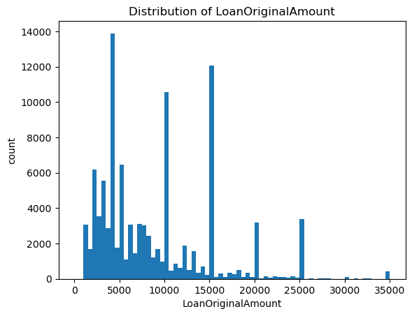

```python
#setting bin
bins = np.arange(0, prosperLoan_new['LoanOriginalAmount'].max()+500, 500)
plotDristibution('LoanOriginalAmount',bins=bins)
plt.show()
```

### Risk score

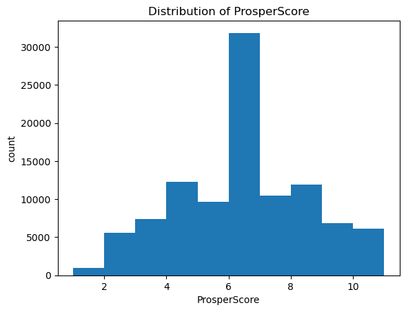

```python
plotDristibution('ProsperScore')
plt.show()
```

### StatedMonthlyIncome

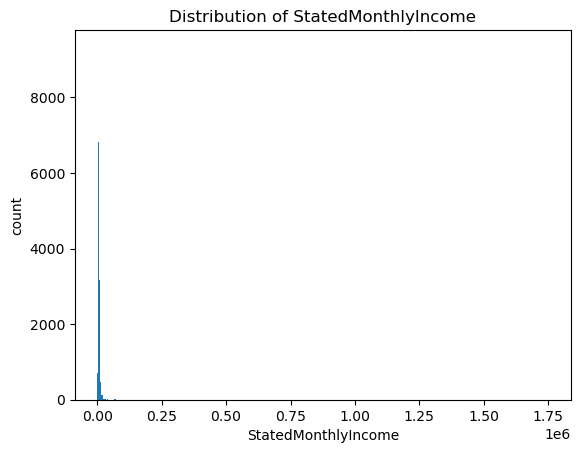

```python
bins = np.arange(prosperLoan_new['StatedMonthlyIncome'].min(), prosperLoan_new['StatedMonthlyIncome'].max()+500,500)
plotDristibution('StatedMonthlyIncome', bins = bins)
plt.show()
```

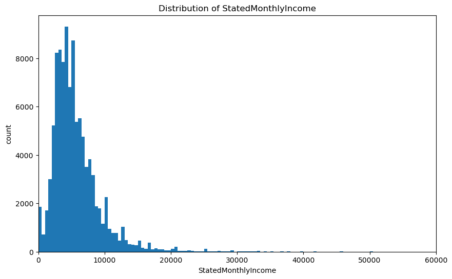

```python
#using xlim to make more readable plot
plt.figure(figsize=[10, 6])
plotDristibution('StatedMonthlyIncome', bins = bins)
plt.xlim(0,60000)
plt.show()
```

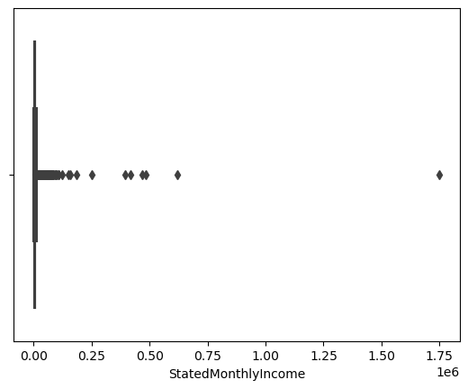

```python
#Plotting a box plot with Stated monthly income variable to check for outliers
sns.boxplot(prosperLoan_new['StatedMonthlyIncome'])
plt.xlabel('StatedMonthlyIncome')
plt.show()
```

The distribution is skewed to the right indicating large amount of outliers

```python
# Using IQR method to detect lower and upper limit
Q1 = prosperLoan_new['StatedMonthlyIncome'].quantile(0.25)
Q3 = prosperLoan_new['StatedMonthlyIncome'].quantile(0.75)
IQR = Q3 - Q1
LowerLimit = Q1 - 1.5*IQR  #Data which falls below this is an outlier
UpperLimit = Q3 + 1.5*IQR  #Data which falls above this is an outlier
print(LowerLimit, UpperLimit)
```

```
-2116.6666680000003 12416.666668000002
```

```python
#cutting off outliers
transform_prosper_loan = prosperLoan_new[prosperLoan_new.StatedMonthlyIncome < UpperLimit]
```

The borrowers' monthly income stated before borrowing the money, on average, falls between the 4000 and 7000 dollar range.

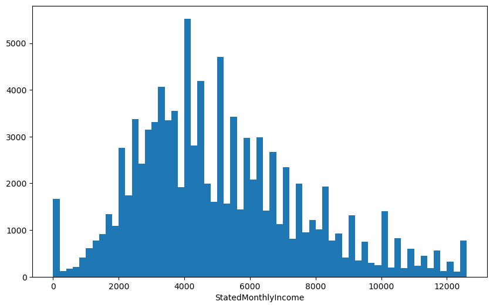

```python
#Using transform_prosper_loan['StatedMonthlyIncome'] min and max  to set the width of the bin to cut of outlier
bins = np.arange(transform_prosper_loan['StatedMonthlyIncome'].min(), transform_prosper_loan['StatedMonthlyIncome'].max()+200,200)
plt.figure(figsize=[10, 6])
plt.hist(data = prosperLoan_new, x = 'StatedMonthlyIncome', bins=bins)
plt.xlabel('StatedMonthlyIncome')
plt.show()
```

### TradesNeverDelinquent (percentage)

More than 50% of trades have never been delinquent at the time when most credit profiles were pulled, indicating lower loan delinquency rates when most loans were requested by the borrower.

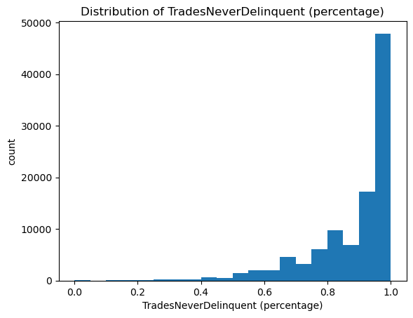

```python
bins = np.arange(prosperLoan['TradesNeverDelinquent (percentage)'].min(),prosperLoan['TradesNeverDelinquent (percentage)'].max()+0.05,0.05)
plotDristibution('TradesNeverDelinquent (percentage)', bins = bins)
plt.show()
```

### DebtToIncomeRatio

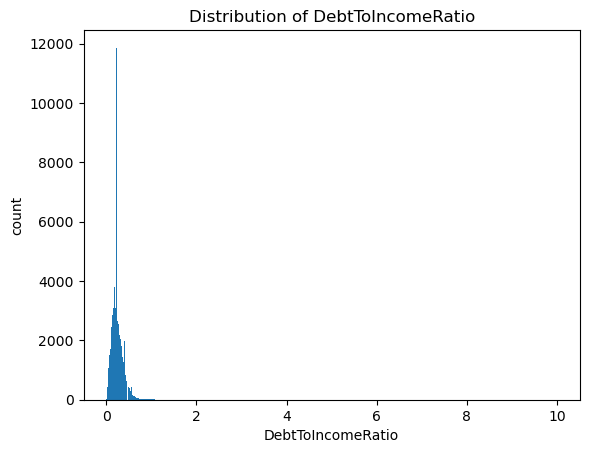

```python
# DebtToIncomeRatio
bins = np.arange(prosperLoan_new.DebtToIncomeRatio.min(),prosperLoan.DebtToIncomeRatio.max(),0.01)
plotDristibution('DebtToIncomeRatio', bins = bins)
plt.show()
```

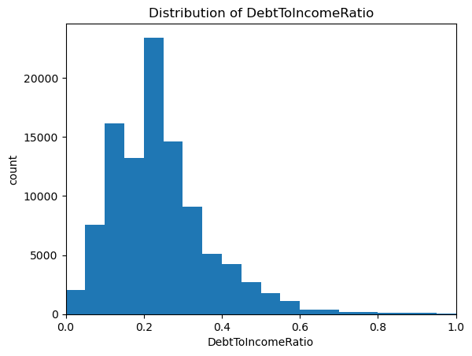

```python
#Using xlim to o specify the maximum values of the x-axis
bins = np.arange(prosperLoan_new.DebtToIncomeRatio.min(),prosperLoan.DebtToIncomeRatio.max(),0.05)
plotDristibution('DebtToIncomeRatio', bins = bins)
plt.xlim(0,1)
plt.show()
```

### MonthlyLoanPayment

The distribution of scheduled monthly loan payments is unimodal, with many borrowers making a payment around 200 dollars. Most of the scheduled monthly loan payments are below 500 dollars.

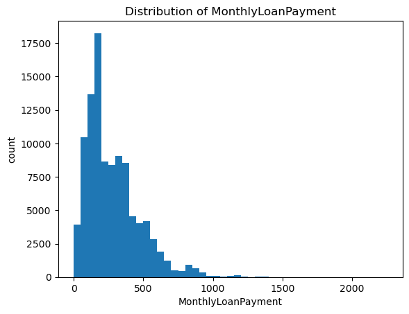

```python
bins = np.arange(prosperLoan_new.MonthlyLoanPayment.min(),prosperLoan.MonthlyLoanPayment.max(),50)
plotDristibution('MonthlyLoanPayment', bins = bins)
plt.show()
```

### BorrowerAPR

For most loans, the distribution of the Borrower's Annual Percentage Rate (APR) peaks at 20%, with fewer borrowers opting for loans with APRs higher than 20%.

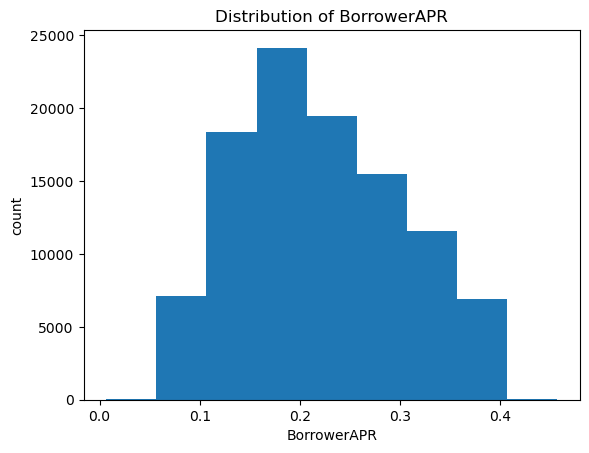

```python
bins = np.arange(prosperLoan_new['BorrowerAPR'].min(), prosperLoan_new['BorrowerAPR'].max()+0.05, 0.05)
plotDristibution('BorrowerAPR', bins = bins)
plt.show()
```

### LenderYield

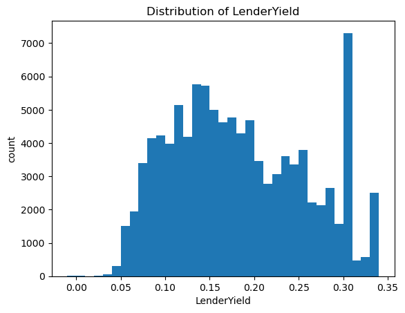

```python
bins = np.arange(prosperLoan_new['LenderYield'].min(), prosperLoan_new['LenderYield'].max()+0.01, 0.01)
plotDristibution('LenderYield', bins = bins)
plt.show()
```

### Investors

For most loans, the number of investors is below 100

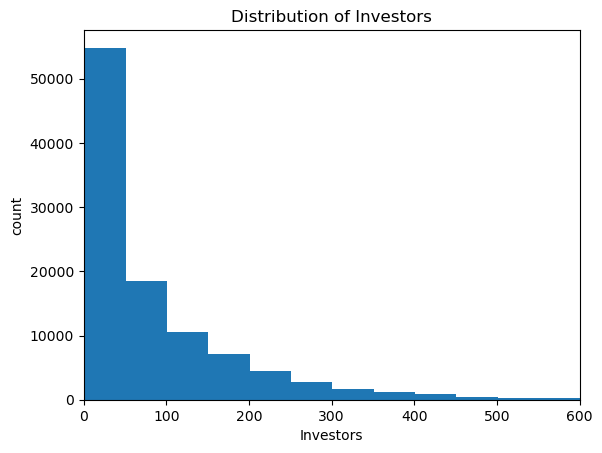

```python
bins = np.arange(prosperLoan_new['Investors'].min(), prosperLoan_new['Investors'].max()+50,50)
plotDristibution('Investors', bins = bins)
plt.xlim(0,600)
plt.show()
```

### EmploymentStatusDuration

The employment status duration of most borrowers is below 200.

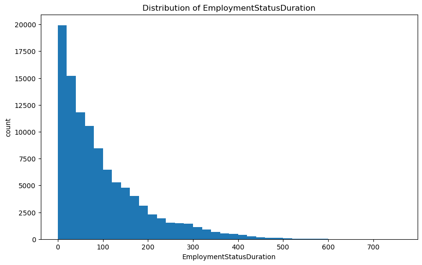

```python
bins = np.arange(0, prosperLoan.EmploymentStatusDuration.max()+20, 20)
plt.figure(figsize=[10, 6])
plotDristibution('EmploymentStatusDuration', bins = bins)
plt.show()
```

## Moving to Categorical variable

```python
### Creating Function for coumtplot
def countPlot(variable,color= base_color,order=None):
    sns.countplot(data = prosperLoan_new, x = variable,color = color,order = order)
    plt.title(f'countplot of {variable}')
    plt.xticks(rotation = 90)
```

### LoanStatus

The majority of loans are still active, followed by loans that have been completed, while a smaller proportion of loans have been cancelled.

[figure not shown]

```python
order = prosperLoan_new.LoanStatus.value_counts().index
countPlot('LoanStatus',order=order)
plt.yscale('log')
plt.yticks([10e1,10e2,10e3,10e4,10e5],[10,100,1000,10000,100000])
plt.show()
```

### EmploymentStatus

The majority of borrowers were employed and working full time, while the retired and unemployed accounted for the smallest proportion of borrowers who were given loans.

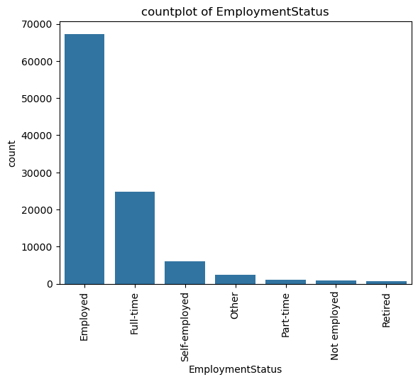

```python
order = prosperLoan_new['EmploymentStatus'].value_counts().index
countPlot('EmploymentStatus',order=order)
plt.show()
```

### ListingCategory

Debt consolidation is the most frequently cited reason for taking out a loan by the majority of borrowers.

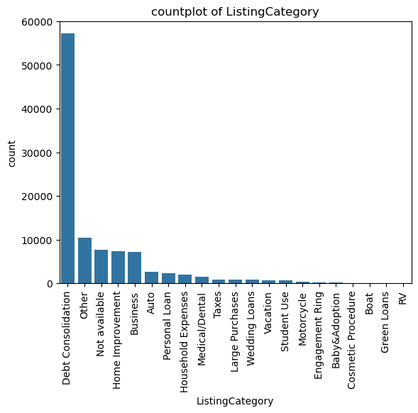

```python
order = prosperLoan_new["ListingCategory"].value_counts().index
countPlot('ListingCategory',order=order)
plt.show()
```

### ProsperRating (Alpha)

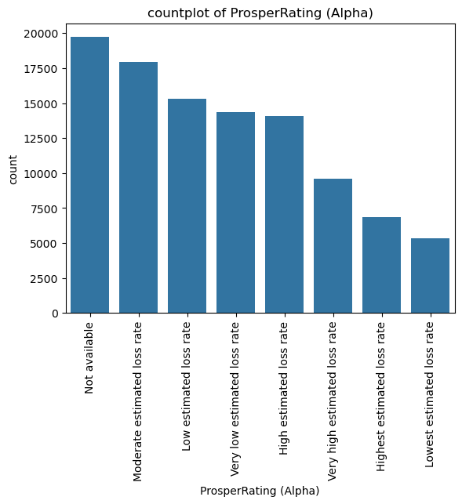

```python
# ProsperRating distribution.
order = prosperLoan_new['ProsperRating (Alpha)'].value_counts().index
countPlot('ProsperRating (Alpha)',order=order)
plt.show()
```

### IsBorrowerHomeowner

The percentage of borrowers who own a home was slightly higher than the percentage of borrowers who do not own a home.

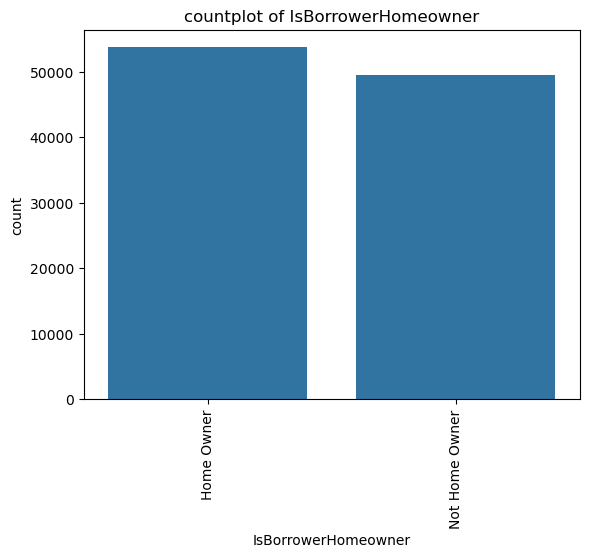

```python
countPlot('IsBorrowerHomeowner')
plt.show()
```

### Occupation

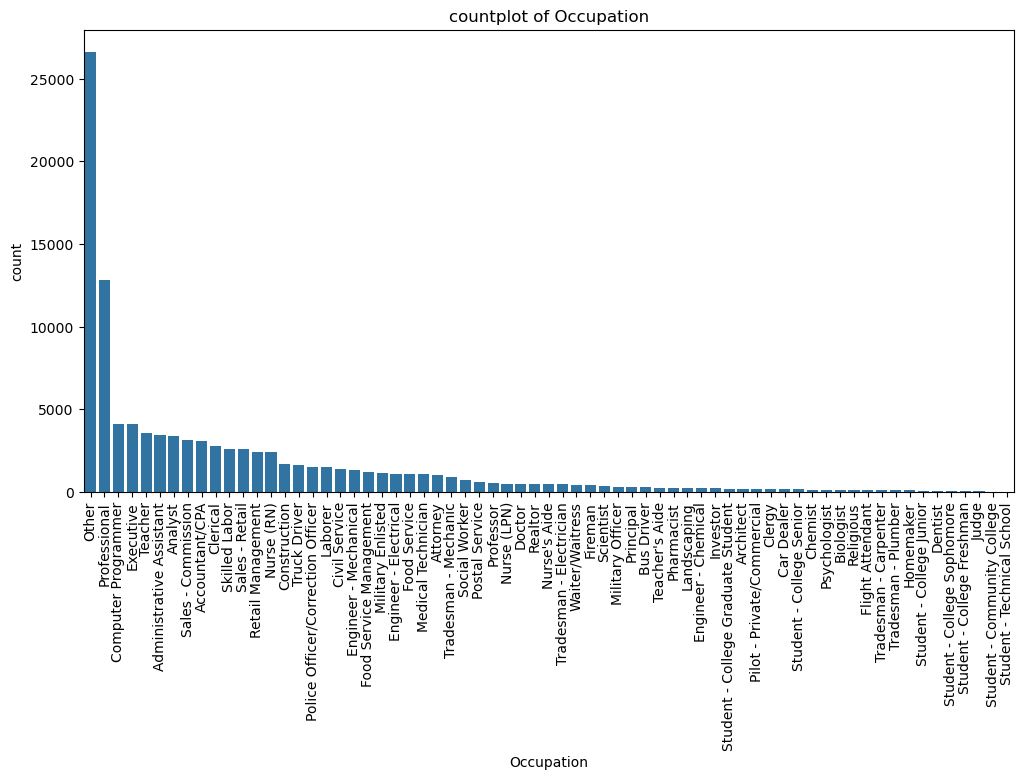

```python
order =prosperLoan_new['Occupation'].value_counts().index
plt.figure(figsize=[12, 6])
countPlot('Occupation',order=order)
plt.show()
```

### Loan Term Occurence

The most frequently chosen loan duration among borrowers was a middle term of approximately 36 months, suggesting that the majority of borrowers prefer loans with a moderate duration rather than opting for short-term or long-term loans.

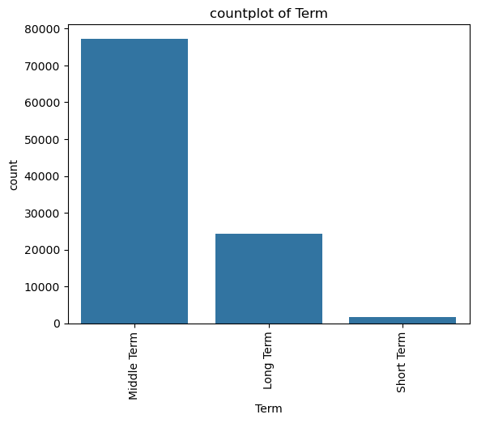

```python
countPlot('Term')
plt.show()
```

### IncomeVerifiable

As per standard practice, the majority of the borrowers' income sources were verified prior to the loans being granted.

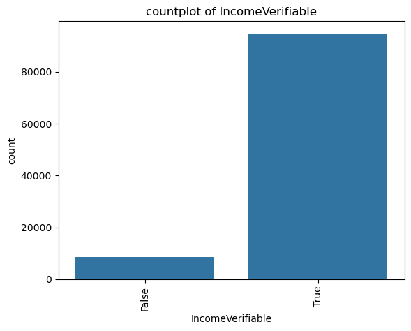

```python
countPlot('IncomeVerifiable')
plt.show()
```

### BorrowerState

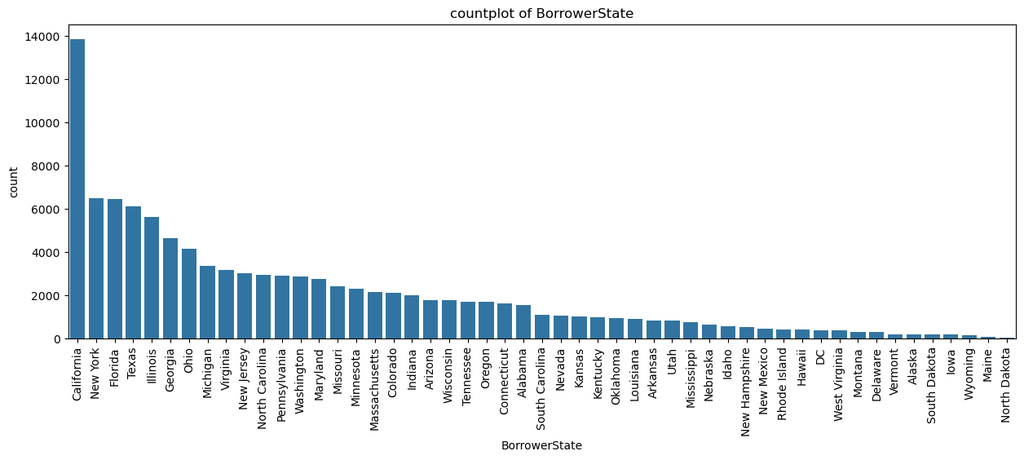

```python
plt.figure(figsize = [15, 5])
order=prosperLoan_new['BorrowerState'].value_counts().index
countPlot('BorrowerState', order =order)
plt.show()
```

### Discuss the distribution(s) of your variable(s) of interest. Were there any unusual points? Did you need to perform any transformations?

LoanOriginalAmount variable has a range of 1000 to 35000 dollar and appears to have three peaks, with the highest peak just below 5000 dollar mark and the other peaks at 10000 and 15000 dollar mark. there are no outliers or unusual points in the data, so no transformation was performed. For loan status, most loans are still active, followed by completed loans. This implies that a significant proportion of borrowers are currently repaying their loans, while others have successfully completed their loan repayment.

### Using Heatmap to show relationship between numerical variables

Based on the heatmap provided, there is a strong positive correlation between Monthly Loan Payment and Loan Original Amount. This suggests that borrowers who take out larger loans tend to have higher monthly payments.

There is also a weak positive correlation between Loan Original Amount and the number of investors, indicating that loans with higher amounts tend to attract more investors.

Furthermore, there appears to be a slightly weak negative correlation between Borrower APR and Loan Original Amount, as well as between Lender Yield and Loan Original Amount. This suggests that borrowers who take out larger loans may receive lower APRs and that lenders may receive lower yields on larger loans.

There is also a fair negative relationship between Properscore and Lender Yield, indicating that borrowers with lower Properscores may receive higher Lender Yields.

Finally, there is a high positive correlation between Lender Yield and Borrower APR, suggesting that loans with higher Borrower APRs tend to have higher Lender Yields.

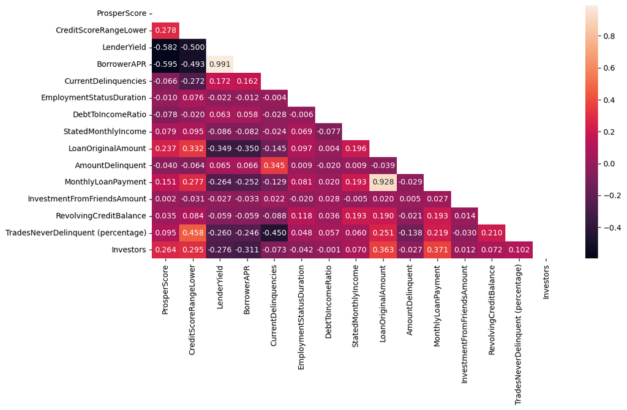

```python
# Heatmap
mask = np.zeros_like(prosperLoan_new[num_cols].corr())
upper_part = np.triu_indices_from(mask)
mask[upper_part] = 1
plt.figure(figsize = [12, 6])
sns.heatmap(prosperLoan_new[num_cols].corr(), annot = True, fmt = '.3f', mask = mask,)
plt.show()
```

### Pairplot to show relationship between Loan Original Amount and other factors

It is expected to observe a strong correlation between LoanOriginalAmount and MonthlyLoanPayment since borrowers who agree to make higher monthly payments are likely to be granted larger loan amounts. Additionally, there is a positive correlation between LoanOriginalAmount and StatedMonthlyIncome, which suggests that borrowers with higher incomes are more likely to be approved for larger loans.

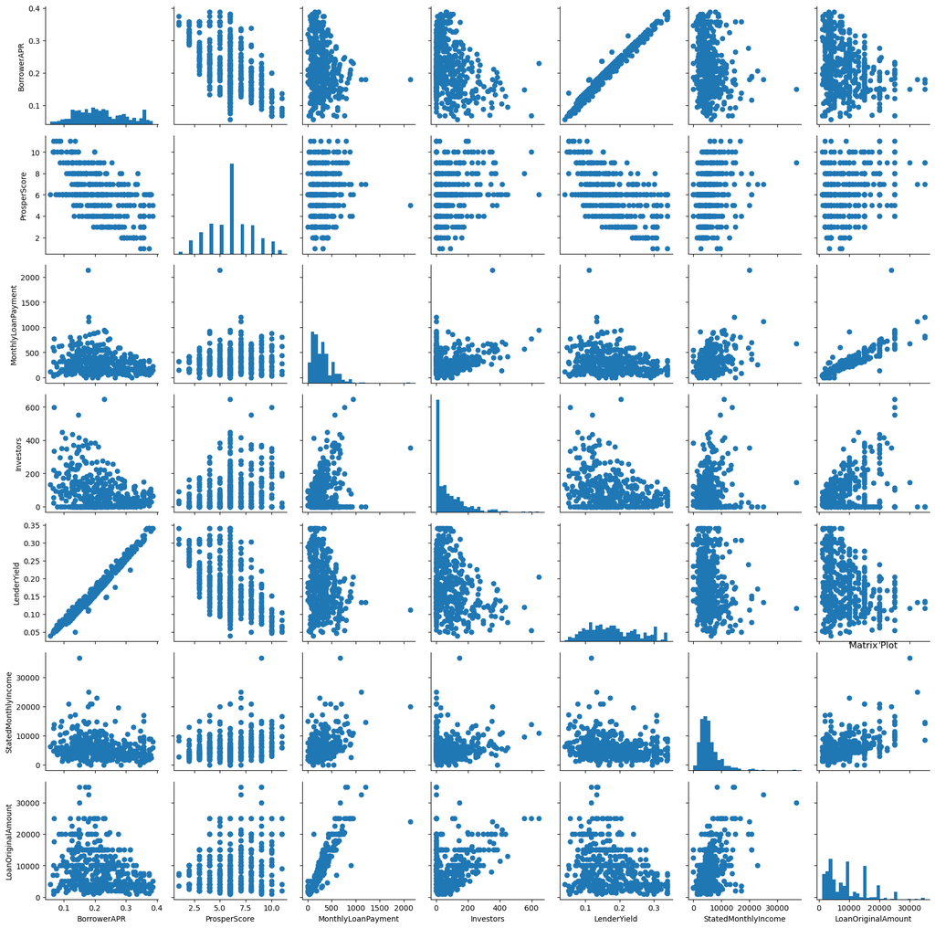

```python
# plot matrix: only 500 random loans are used to see the pattern more clearer
Loan_new = prosperLoan_new.sample(n=500, replace = False)
g = sns.PairGrid(data = Loan_new, vars = ['BorrowerAPR', 'ProsperScore','MonthlyLoanPayment',
                                          'Investors', 'LenderYield', 'StatedMonthlyIncome',
                                          'LoanOriginalAmount'])
g = g.map_diag(plt.hist, bins = 30)
g.map_offdiag(plt.scatter)
plt.title('Matrix Plot');
```

### LoanOriginalAmount' and Term, LoanOriginalAmount' and Employment Status

Long term loans tend to have higher amount than other categories also the boxplot analysis of loan amounts based on employment status shows that employed individuals have the longest range of loan amounts and are more likely to be approved for higher loan amounts compared to self-employed individuals, who also have a relatively high chance of getting high loan amounts. In contrast, unemployed, retiree, and part-time individuals have a much smaller range of loan amounts and are less likely to be approved for higher loan amounts.

[figure not shown]

```python
plt.figure(figsize = [20, 8])
plt.subplot(1, 2, 1)
sns.barplot(data=prosperLoan_new,y='LoanOriginalAmount',x='Term',ci = 0,color=base_color);
plt.xlabel('LoanOriginalAmount');
plt.ylabel('LoanOriginalAmount');
plt.title('LoanOriginalAmount vs Term');

plt.subplot(1, 2, 2)
sns.boxplot(data=prosperLoan_new,x='LoanOriginalAmount',y='EmploymentStatus',color=base_color);
plt.xlabel('LoanOriginalAmount');
plt.ylabel('EmploymentStatus');
plt.title('LoanOriginalAmount vs Employment Status');
```

### Terms and Loan_status

According to the analysis of loan statuses and terms, it can be concluded that the majority of loans that are still active have a middle duration of 36 months. The second highest number of loans are those that have been paid off, and most of them also have a middle duration.

[figure not shown]

```python
plt.figure(figsize = [15, 5])
sns.countplot(data = prosperLoan_new, hue = 'Term', x = 'LoanStatus')
plt.xticks(rotation = 90)
plt.ylabel('LoanOriginalAmount')
plt.title('LoanStatus vs Term')
plt.show()
```

### MonthlyLoanPayment and LoanOriginalAmount

Based on the plot, it appears that there is a strong positive correlation between the Loan Amount and Monthly Loan Payment. This is likely due to the fact that the monthly loan payment is typically calculated based on the loan amount.

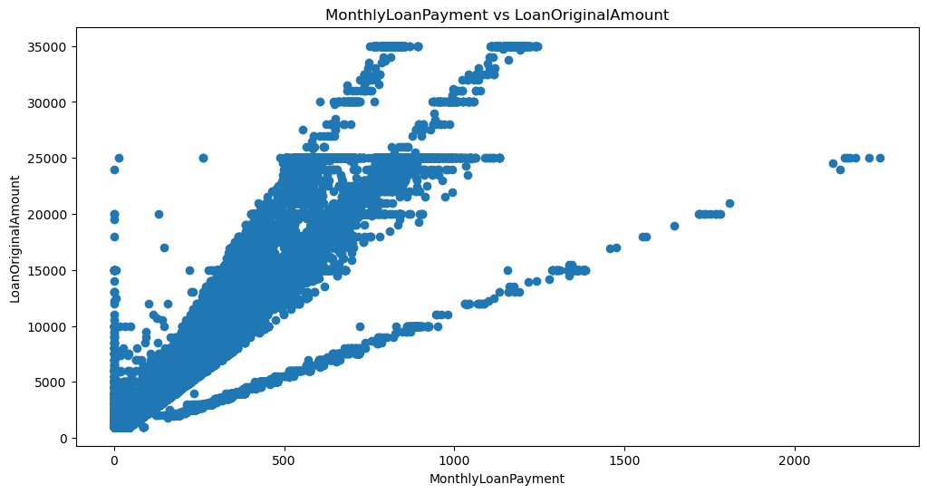

```python
plt.figure(figsize = [12, 6])
plt.scatter(data = prosperLoan_new, x='MonthlyLoanPayment', y='LoanOriginalAmount')
plt.xlabel('MonthlyLoanPayment')
plt.ylabel('LoanOriginalAmount')
plt.title('MonthlyLoanPayment vs LoanOriginalAmount')
plt.show()
```

### LoanOriginalAmount and LenderYield

A higher lender yield typically indicates a higher interest rate, and borrowers tend to borrow smaller amounts of money. Conversely, a lower to fair lender yield tends to allow borrowers to borrow higher loan amounts.

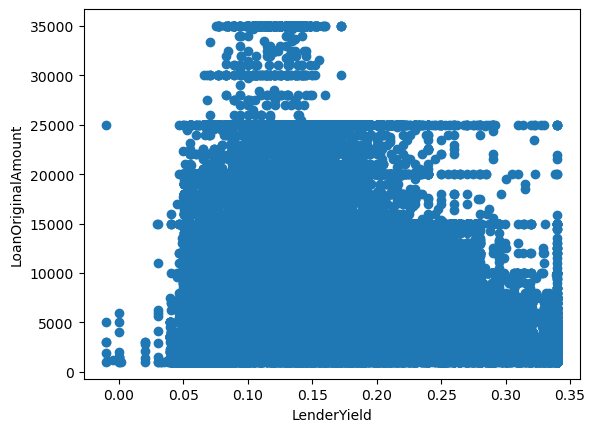

```python
plt.scatter(data = prosperLoan_new, x='LenderYield', y='LoanOriginalAmount')
plt.xlabel('LenderYield')
plt.ylabel('LoanOriginalAmount')
plt.show()
```

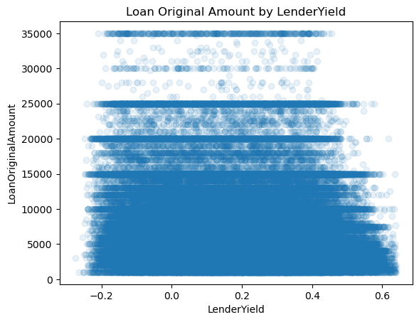

```python
# Using jitter and transparency to help with overplotting
sns.regplot(data = prosperLoan_new, x='LenderYield', y='LoanOriginalAmount', x_jitter=0.3, scatter_kws=({'alpha':1/10}))
plt.title('Loan Original Amount by LenderYield')
plt.show()
```

### IncomeRange and LoanOriginalAmount

Individuals with lower income tend to apply for loans of less than 10,000 dollars, while those with higher income ranges of 50,000 dollars or more are more likely to be approved for higher loan amounts. Additionally, homeowners are more likely to secure higher loan amounts compared to non-homeowners, as non-homeowners mostly dominate loans under the 10,000 dollar mark.

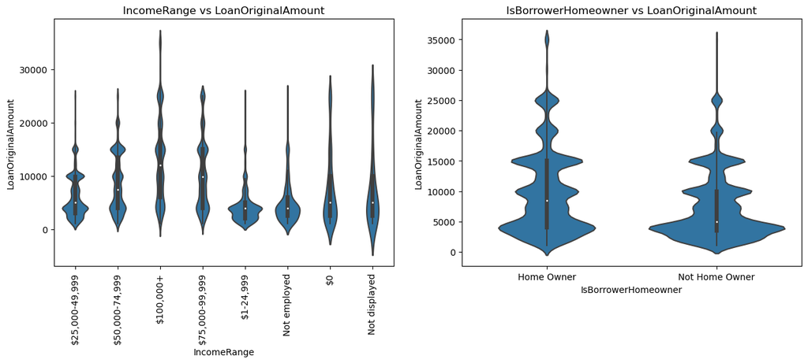

```python
plt.figure(figsize = [15, 5])
plt.subplot(1, 2, 1)
sns.violinplot(data = prosperLoan_new, x = 'IncomeRange', y = 'LoanOriginalAmount',color=base_color)
plt.xticks(rotation = 90)
plt.title('IncomeRange vs LoanOriginalAmount')

plt.subplot(1, 2, 2)
sns.violinplot(data = prosperLoan_new, x = 'IsBorrowerHomeowner', y = 'LoanOriginalAmount',color=base_color)
plt.title('IsBorrowerHomeowner vs LoanOriginalAmount')
plt.show()
```

### LoanOriginalAmount and Risk

loans with high ProsperScore are associated with higher loan amounts compared to those with low ProsperScore. This can be attributed to the fact that ProsperScore is a measure of risk, with high scores indicating low risk and low scores indicating high risk. Therefore, loans with low ProsperScore are considered risky and typically involve smaller loan amounts.

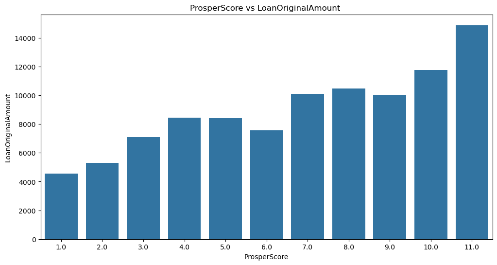

```python
plt.figure(figsize=[12, 6])
sns.barplot(data = prosperLoan_new, x='ProsperScore', y='LoanOriginalAmount', color=base_color,ci = 0)
plt.title('ProsperScore vs LoanOriginalAmount ')
plt.show()
```

### LenderYield and Term

middle-term loans, which are a popular option among borrowers, have a wider range of lender yields compared to short-term and long-term loans. Despite this, the average lender yield for middle-term loans is generally slightly lower than that of long-term loans which is the highest and have a narrower yield range. This could be due to the fact that middle-term loans are in higher demand than short-term and long-term loans.

short-term loans have higher monthly loan payments than other loan terms, such as middle-term and long-term loans. This may be because short-term loans have a shorter repayment period, which means that borrowers have to make higher monthly payments to repay the loan in a shorter amount of time.

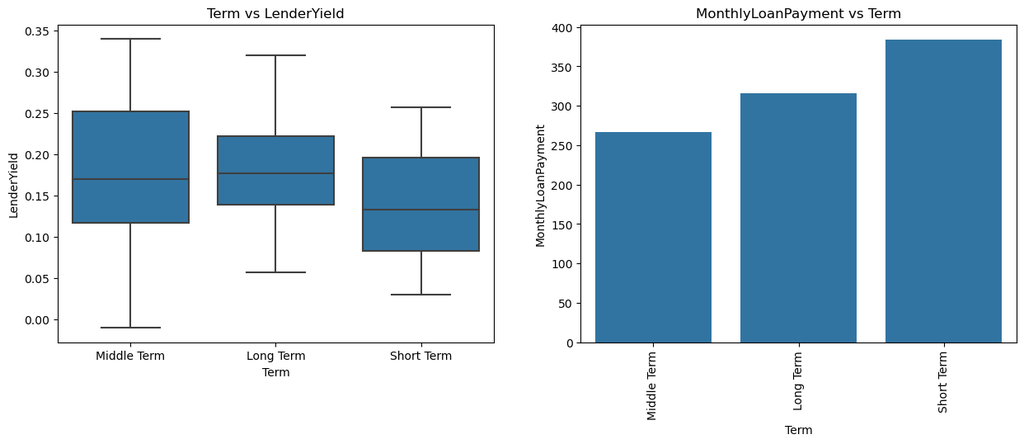

```python
plt.figure(figsize = [15, 5])
plt.subplot(1, 2, 1)
sns.boxplot(data=prosperLoan_new, x='Term', y='LenderYield',color=base_color);
plt.title('Term vs LenderYield')

plt.subplot(1, 2, 2)
sns.barplot(data = prosperLoan_new, x = 'Term', y = 'MonthlyLoanPayment',ci = 0,color=base_color)
plt.xticks(rotation = 90)
plt.title('MonthlyLoanPayment vs Term')
plt.show()
```

### LoanStatus & BorrowerAPR, LoanStatus & LenderYield

Defaulted or overdue loans typically exhibit higher lender yield and borrower APR compared to loans that are currently active or have been fully paid off.

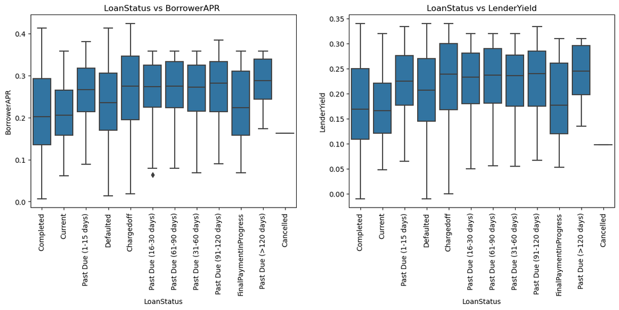

```python
plt.figure(figsize = [15, 5])
plt.subplot(1, 2, 1)
sns.boxplot(data=prosperLoan_new, x='LoanStatus', y='BorrowerAPR',color=base_color);
plt.xticks(rotation = 90)
plt.title('LoanStatus vs BorrowerAPR ')

plt.subplot(1, 2, 2)
sns.boxplot(data=prosperLoan_new, x='LoanStatus', y='LenderYield',color=base_color);
plt.xticks(rotation = 90)
plt.title('LoanStatus vs LenderYield')
plt.show()
```

```python
### LoanStatus & TradesNeverDelinquent (percentage)
```

Canceled loans exhibit the lowest percentage of trades that were never delinquent at the time the credit profile was checked, indicating that canceled loans may have a higher overall number of delinquencies. This suggests that most canceled loans may have been granted to higher-risk borrowers who were more likely to default.

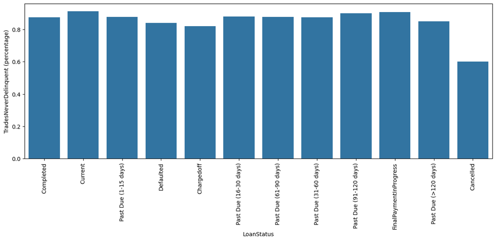

```python
plt.figure(figsize = [15, 5])
sns.barplot(data=prosperLoan_new, x='LoanStatus', y='TradesNeverDelinquent (percentage)',color=base_color,ci = 0);
plt.xticks(rotation = 90)
plt.show()
```

### LoanStatus vs Investors

Default loans surprisingly have the largest number of investors,followed by complete loans

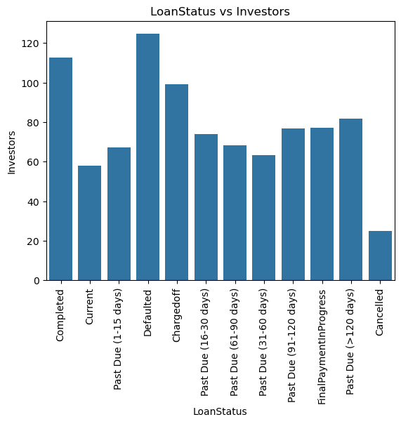

```python
sns.barplot(data=prosperLoan_new, x='LoanStatus', y='Investors',color=base_color,ci =0);
plt.xticks(rotation = 90)
plt.title('LoanStatus vs Investors')
plt.show()
```

### ProsperRating (Alpha) vs MonthlyLoanPayment and AmountDelinquent vs ProsperRating (Alpha)

Generally, loans with lower estimated loss rates have slightly higher monthly payments compared to loans with higher estimated loss rates. Conversely, for the amount delinquent, loans with higher estimated loss rates have a more significant amount of delinquent payments compared to loans with lower estimated loss rates.

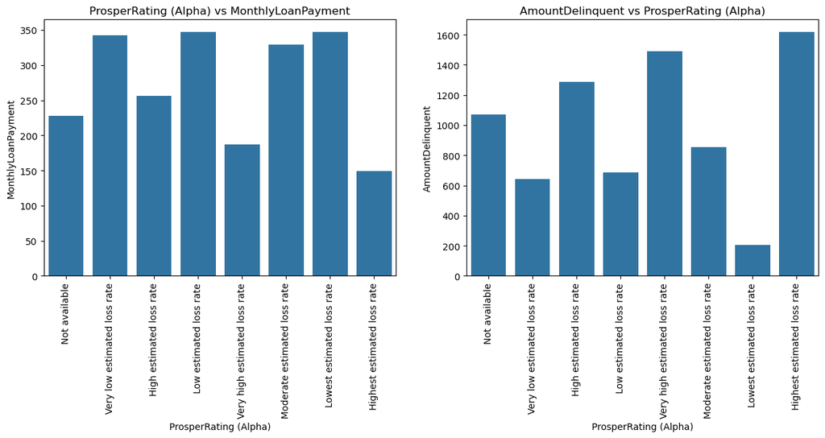

```python
plt.figure(figsize = [15, 5])
plt.subplot(1, 2, 1)
sns.barplot(data = prosperLoan_new, x = 'ProsperRating (Alpha)', y = 'MonthlyLoanPayment',color=base_color,ci = 0)
plt.xticks(rotation = 90)
plt.title('ProsperRating (Alpha) vs MonthlyLoanPayment' )

plt.subplot(1, 2, 2)
sns.barplot(data = prosperLoan_new, x = 'ProsperRating (Alpha)', y = 'AmountDelinquent',color=base_color,ci = 0)
plt.xticks(rotation = 90)
plt.title('AmountDelinquent vs ProsperRating (Alpha)' )
plt.show()
```

## Talk about some of the relationships you observed in this part of the investigation. How did the feature(s) of interest vary with other features in the dataset?

A significant finding is that there is a strong positive correlation between loan amount and monthly loan payment. Borrowers with lower monthly incomes tend to receive lower loan amounts, while those with higher incomes are approved for higher loan amounts. Moreover, loans with high Prosper Scores are associated with higher loan amounts compared to those with low Prosper Scores. Cancelled loans generally have the lowest loan amounts, while active and servicing loans have the highest loan amounts. However, loans that become overdue or default tend to have a higher lender yield and borrower APR compared to loans that are currently active or have been fully paid off.

### Did you observe any interesting relationships between the other features (not the main feature(s) of interest)?

it was observe that most borrowers tend to opt for a medium-term loan of 36 months, which is associated with a wider range of lender yields. Another noteworthy discovery is that loans with lower estimated loss rates have a lower delinquency rate and require higher monthly payments compared to loans with higher estimated loss rates. Default loans surprisingly have the largest number of investors.

### Multivariate Exploration

In this section, I'll create plots of three or more variables to investigate relationship between main features and other variables

### Loan Original Amount,Loan Status and LoanTerms

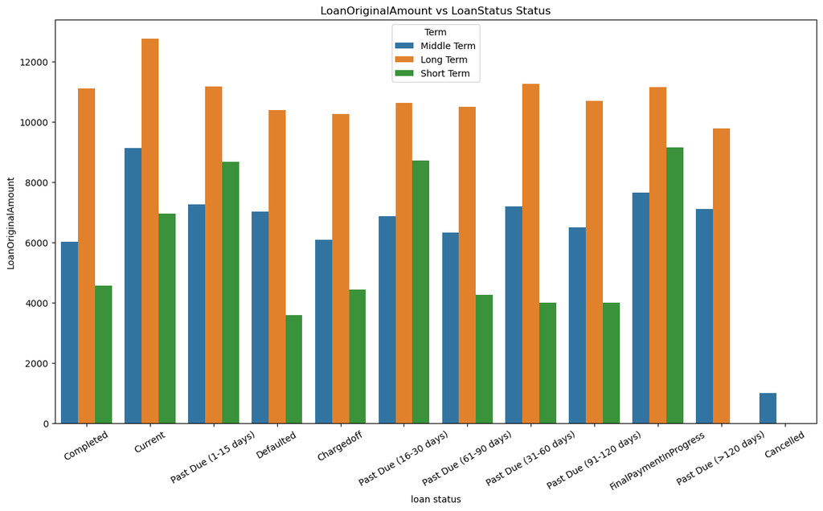

```python
plt.figure(figsize=[15, 8])
sns.barplot(data=prosperLoan_new,y='LoanOriginalAmount',x='LoanStatus',ci =0,hue = 'Term');
plt.xlabel('loan status');
plt.ylabel('LoanOriginalAmount');
plt.xticks(rotation = 30)
plt.title('LoanOriginalAmount vs LoanStatus Status');
```

### Trend of Loan Amount Over the years

The trend of loan originations has generally been increasing over the years. Long-term loans experienced a dip from 2010 to 2012 before rising again. Long-term loans are typically associated with larger loan amounts, while short-term loans are generally for smaller amounts. Middle-term loans fall in between the two in terms of loan amount. most canceled loans may have been granted to higher-risk borrowers who were more likely to default

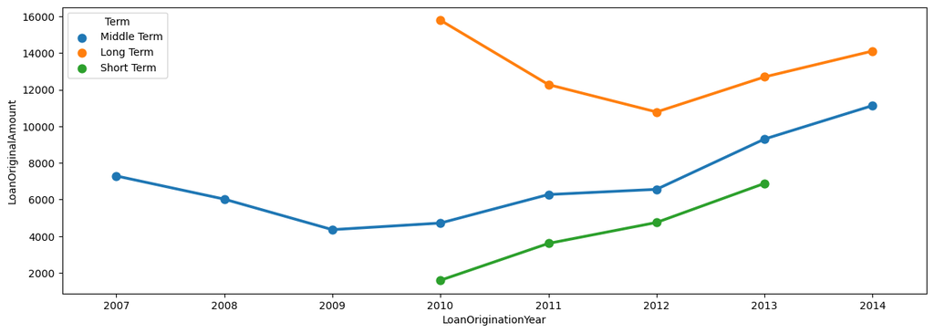

```python
plt.figure(figsize = [15, 5])
# sort_prosperLoan_new = prosperLoan_new.sort_values(by='LoanOriginationYear', key = lambda x: x.astype(int))
sns.pointplot(x='LoanOriginationYear', y='LoanOriginalAmount',
             data=prosperLoan_new.sort_values(by='LoanOriginationYear', key = lambda x: x.astype(int)),
             hue = 'Term',ci =0)
```

### Loan Original Amount, Monthly Loan Payment across loan Term

Short-term loans are more likely to be repaid compared to other types of loans, and there is a strong positive relationship between the monthly loan payment and the loan amount for all types of loans, particularly short-term loans. This may be due to the fact that short-term loans have smaller loan amounts and corresponding monthly payments, which makes it easier for borrowers to complete the loan quickly.

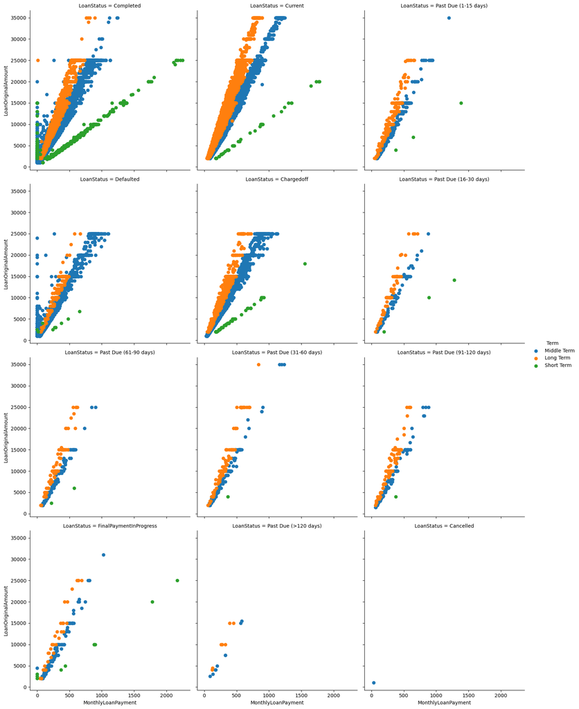

```python
g = sns.FacetGrid(data = prosperLoan_new, hue = 'Term', size = 5,col= 'LoanStatus', col_wrap=3)
g.map(plt.scatter, 'MonthlyLoanPayment', 'LoanOriginalAmount')
g.add_legend()
```

### LoanStatus,LenderYield and EmploymentStatus

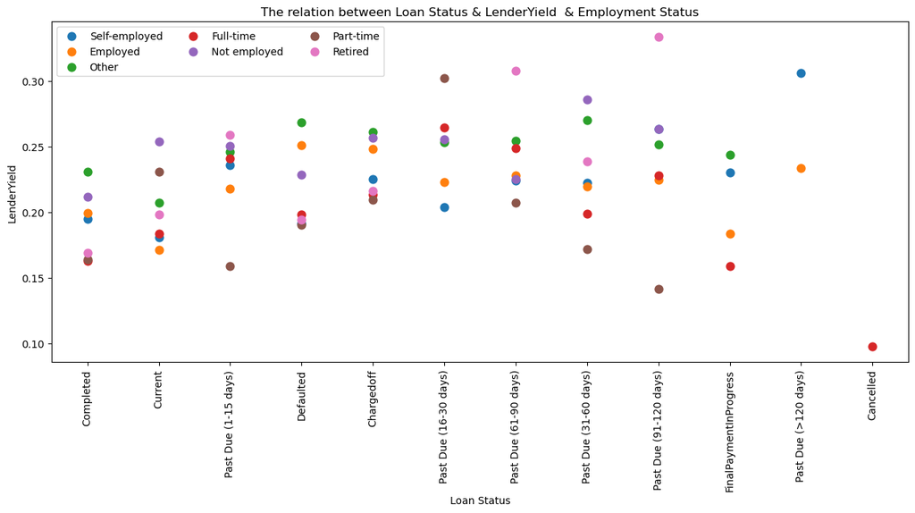

```python
plt.figure(figsize=[15,6])
sns.pointplot(data= prosperLoan_new,x="LoanStatus",y="LenderYield",hue="EmploymentStatus",linestyles="",ci = 0);
plt.xticks(rotation =90);
plt.legend(ncol=3);
plt.ylabel("LenderYield")
plt.xlabel("Loan Status");
plt.title("The relation between Loan Status & LenderYield  & Employment Status");
```

### ListingCategory & LoanOriginalAmount & Term

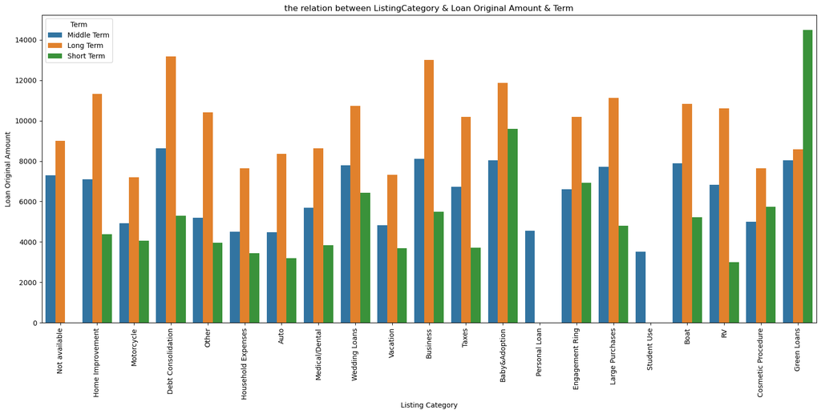

```python
plt.figure(figsize=[20,8])
sns.barplot(data= prosperLoan_new,x="ListingCategory",y="LoanOriginalAmount",hue="Term",ci = 0);
plt.xlabel("Listing Category");
plt.ylabel("Loan Original Amount");
plt.title("the relation between ListingCategory & Loan Original Amount & Term");
plt.xticks(rotation =90);
```

### Loan Original Amount Across Loan Term and Prosper Score

The plot confirms that short-term loans typically have smaller loan amounts, regardless of the borrower's ProsperScore rating. Middle-term loans with high ProsperScore ratings are more likely to be approved for larger loan amounts, while long-term loans with high ProsperScore ratings are the most preferred for obtaining the largest loan amounts.

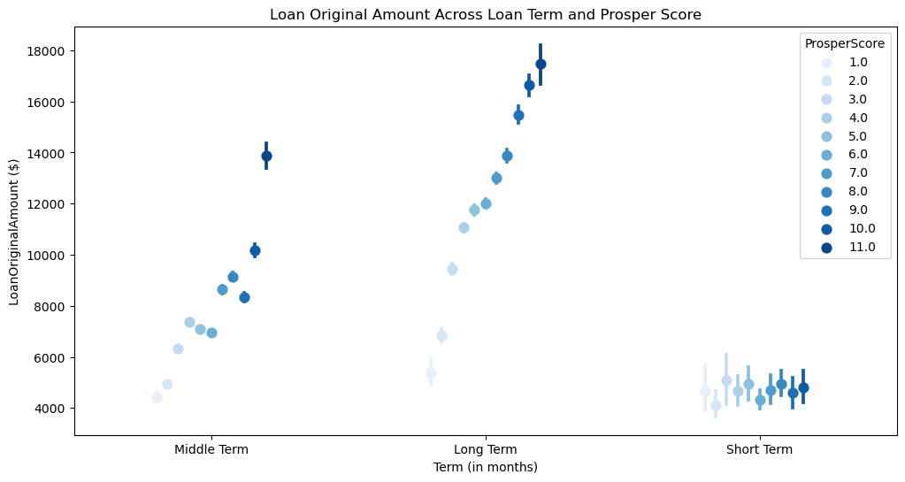

```python
plt.figure(figsize = [12, 6])
sns.pointplot(data = prosperLoan_new, x = 'Term', y = 'LoanOriginalAmount', hue = 'ProsperScore',palette = 'Blues', linestyles = '', dodge = 0.4)
plt.title('Loan Original Amount Across Loan Term and Prosper Score')
plt.ylabel('LoanOriginalAmount ($)')
plt.xlabel('Term (in months)')
plt.show()
```

## Conclusions

During the data exploration process, I took the following steps:

- Imported the necessary packages and loaded the data, then reviewed the data dictionary to understand the variables.
- Conducted preliminary data wrangling to clean and prepare the data for analysis.
- Created a subset of the dataframe that included the variables I was interested in exploring.
- Conducted univariate plotting to explore the distribution of the main features (Loan Original Amount and Loan status) and predictor variables, introducing each variable before diving into the next.
- Used a standard heat map to show the relationship between the numerical variables and plotted scatterplot subplots to investigate further.
- Created a matrix plot grid to understand how categorical variables affected main features (particularly Loan Amount).
- Used individual plots to show the relationships between the main variables and predictor variables
- Also, used bar plots to show which categorical features received the most loan amounts.
- Delved into multivariate plotting to identify any features that could strengthen the observed relationships, and discovered some.

## Summary of my findings

In summary, the features that determine loan amount and loan status include Monthly Loan Payment, Loan Original Amount, Stated Monthly Income, ProsperScore, Borrower APR, Lender Yield, loan term, and employment status.